# Week 11 Regression Analysis in R

Jonathan Hernandez

November 3, 2018

```
Using R, build a  regression model for data that interests you.  Conduct residual analysis.
Was the linear model appropriate? Why or why not?
```

### For this discussion, I will look at Kaggle’s Powerlifting Database dataset.

- It’s a dataset containing competitor results in powerlifting from the

OpenPowerlifting Database and do residual analysis.

I will build a simple linear regression model of body weights vs best bench press for seniors to see if

a linear relation exists between them.

- Dataset can be found here: https://www.kaggle.com/open-powerlifting/powerlifting-database
- Overview: https://www.kaggle.com/open-powerlifting/powerlifting-database/home
- Get the data and examine a preview

```r
library(data.table)
powerlift <- fread("openpowerlifting.csv")
head(powerlift, n=5)
```

```
##    MeetID             Name Sex  Equipment Age    Division BodyweightKg
## 1:      0 Angie Belk Terry   F      Wraps  47   Mst 45-49        59.60
## 2:      0      Dawn Bogart   F Single-ply  42   Mst 40-44        58.51
## 3:      0      Dawn Bogart   F Single-ply  42 Open Senior        58.51
## 4:      0      Dawn Bogart   F        Raw  42 Open Senior        58.51
## 5:      0     Destiny Dula   F        Raw  18  Teen 18-19        63.68
##    WeightClassKg Squat4Kg BestSquatKg Bench4Kg BestBenchKg Deadlift4Kg
## 1:            60       NA       47.63       NA       20.41          NA
## 2:            60       NA      142.88       NA       95.25          NA
## 3:            60       NA      142.88       NA       95.25          NA
## 4:            60       NA          NA       NA       95.25          NA
## 5:          67.5       NA          NA       NA       31.75          NA
##    BestDeadliftKg TotalKg Place  Wilks
## 1:          70.31  138.35     1 155.05
## 2:         163.29  401.42     1 456.38
## 3:         163.29  401.42     1 456.38
## 4:             NA   95.25     1 108.29
## 5:          90.72  122.47     1 130.47
```

- Summary of the data

```r
summary(powerlift)
```

```
##      MeetID         Name               Sex             Equipment
##  Min.   :   0   Length:386414      Length:386414      Length:386414
##  1st Qu.:2979   Class :character   Class :character   Class :character
##  Median :5960   Mode  :character   Mode  :character   Mode  :character
##  Mean   :5143
##  3rd Qu.:7175
##  Max.   :8481
##
##       Age           Division          BodyweightKg    WeightClassKg
##  Min.   : 5.00    Length:386414      Min.   : 15.88   Length:386414
##  1st Qu.:22.00    Class :character   1st Qu.: 70.30   Class :character
##  Median :28.00    Mode  :character   Median : 83.20   Mode  :character
##  Mean   :31.67                       Mean   : 86.93
##  3rd Qu.:39.00                       3rd Qu.:100.00
##  Max.   :95.00                       Max.   :242.40
##  NA's   :239267                      NA's   :2402
##     Squat4Kg       BestSquatKg        Bench4Kg       BestBenchKg
##  Min.   :-440.5   Min.   :-477.5   Min.   :-360.0   Min.   :-522.50
##  1st Qu.:  87.5   1st Qu.: 127.5   1st Qu.: -90.0   1st Qu.:  79.38
##  Median : 145.0   Median : 174.6   Median :  90.2   Median : 115.00
##  Mean   : 107.0   Mean   : 176.6   Mean   :  45.7   Mean   : 118.35
##  3rd Qu.: 212.5   3rd Qu.: 217.7   3rd Qu.: 167.5   3rd Qu.: 150.00
##  Max.   : 450.0   Max.   : 573.8   Max.   : 378.8   Max.   : 488.50
##  NA's   :385171   NA's   :88343    NA's   :384452   NA's   :30050
##   Deadlift4Kg     BestDeadliftKg      TotalKg          Place
##  Min.   :-461.0   Min.   :-410.0   Min.   :  11.0   Length:386414
##  1st Qu.: 110.0   1st Qu.: 147.5   1st Qu.: 272.2   Class :character
##  Median : 157.5   Median : 195.0   Median : 424.1   Mode  :character
##  Mean   : 113.6   Mean   : 195.0   Mean   : 424.0
##  3rd Qu.: 220.0   3rd Qu.: 238.1   3rd Qu.: 565.0
##  Max.   : 418.0   Max.   : 460.4   Max.   :1365.3
##  NA's   :383614   NA's   :68567    NA's   :23177
##      Wilks
##  Min.   : 13.73
##  1st Qu.:237.38
##  Median :319.66
##  Mean   :301.08
##  3rd Qu.:379.29
##  Max.   :779.38
##  NA's   :24220
```

- Dimensions of the data and its structure

```r
dim(powerlift)
```

```
## [1] 386414     17
```

```r
str(powerlift)
```

```
## Classes 'data.table' and 'data.frame':   386414 obs. of  17 variables:
##  $ MeetID        : int  0 0 0 0 0 0 0 0 0 0 ...
##  $ Name          : chr  "Angie Belk Terry" "Dawn Bogart" "Dawn Bogart" "Dawn Bogart" ...
##  $ Sex           : chr  "F" "F" "F" "F" ...
##  $ Equipment     : chr  "Wraps" "Single-ply" "Single-ply" "Raw" ...
##  $ Age           : num  47 42 42 42 18 28 60 60 52 52 ...
##  $ Division      : chr  "Mst 45-49" "Mst 40-44" "Open Senior" "Open Senior" ...
##  $ BodyweightKg  : num  59.6 58.5 58.5 58.5 63.7 ...
##  $ WeightClassKg : chr  "60" "60" "60" "60" ...
##  $ Squat4Kg      : num  NA NA NA NA NA ...
##  $ BestSquatKg   : num  47.6 142.9 142.9 NA NA ...
##  $ Bench4Kg      : num  NA NA NA NA NA NA NA NA NA NA ...
##  $ BestBenchKg   : num  20.4 95.2 95.2 95.2 31.8 ...
##  $ Deadlift4Kg   : num  NA NA NA NA NA NA NA NA NA NA ...
##  $ BestDeadliftKg: num  70.3 163.3 163.3 NA 90.7 ...
##  $ TotalKg       : num  138.3 401.4 401.4 95.2 122.5 ...
##  $ Place         : chr  "1" "1" "1" "1" ...
##  $ Wilks         : num  155 456 456 108 130 ...
##  - attr(*, ".internal.selfref")=<externalptr>
```

- Grab rows such that the Best Bench Press > 0 (those competitors who were most likley disqualified) and Division as Seniors and extract just the 2 attributes in question

```r
library(dplyr)
powerlift_senior <- powerlift %>% filter(BestBenchKg > 0 & Division %like% 'Senior') %>%
  select(BodyweightKg, BestBenchKg)
```

### Visualize the data (EDA)

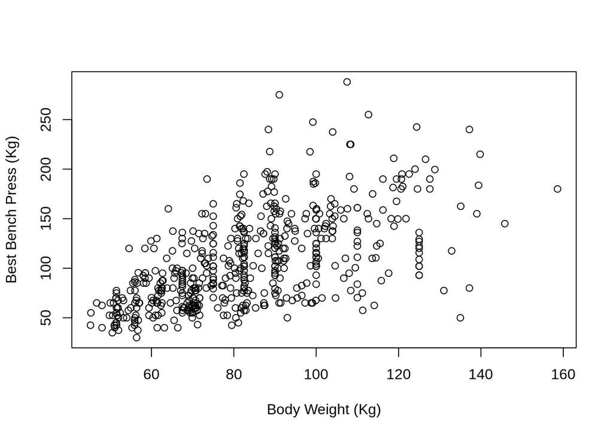

```r
with(powerlift_senior, plot(BodyweightKg, BestBenchKg, xlab = "Body Weight (Kg)",
                            ylab = "Best Bench Press (Kg)"))
```

### Residual Analysis

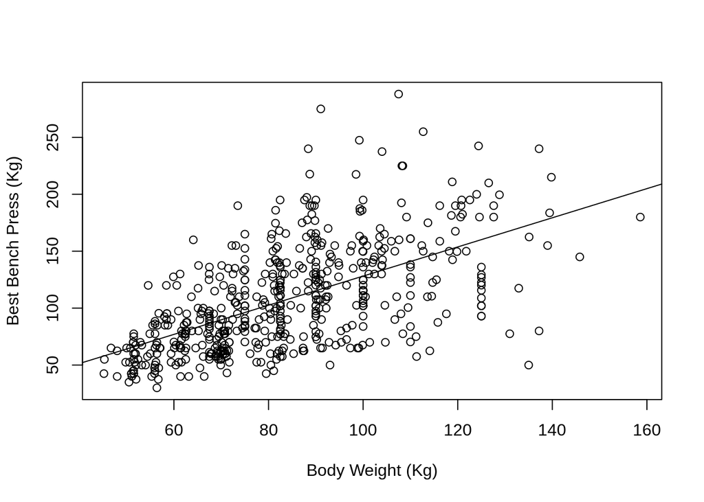

```r
lm_powerlift_senior <- lm(BestBenchKg ~ BodyweightKg, data = powerlift_senior)
with(powerlift_senior, plot(BodyweightKg, BestBenchKg,xlab = "Body Weight (Kg)",
                            ylab = "Best Bench Press (Kg)"))
abline(lm_powerlift_senior)
```

```r
summary(lm_powerlift_senior)
```

```
##
## Call:
## lm(formula = BestBenchKg ~ BodyweightKg, data = powerlift_senior)
##
## Residuals:
##      Min       1Q   Median       3Q      Max
## -122.985  -24.352   -3.433   20.126  158.286
##
## Coefficients:
##              Estimate Std. Error t value Pr(>|t|)
## (Intercept)   0.13762    6.42581   0.021    0.983
## BodyweightKg  1.28035    0.07453  17.178   <2e-16 ***
## ---
## Signif. codes:  0 '***' 0.001 '**' 0.01 '*' 0.05 '.' 0.1 ' ' 1
##
## Residual standard error: 36.41 on 553 degrees of freedom
##   (10 observations deleted due to missingness)
## Multiple R-squared:  0.348,  Adjusted R-squared:  0.3468
## F-statistic: 295.1 on 1 and 553 DF,  p-value: < 2.2e-16
```

- Equation of line is

$$\begin{aligned}
\widehat{bestbenchpress} = 0.1376 + 1.2804*\widehat{bodyweight}
\end{aligned}$$

- Residual plots

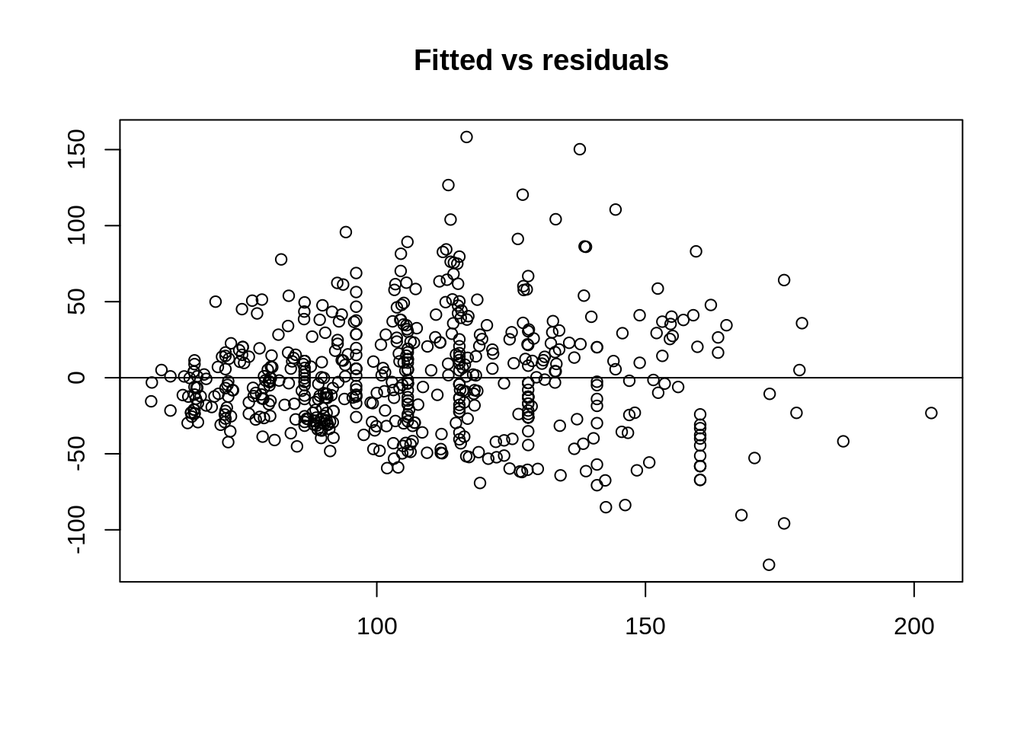

```r
plot(fitted(lm_powerlift_senior), resid(lm_powerlift_senior),
     main = "Fitted vs residuals", xlab = "", ylab = "")
abline(h =0)
```

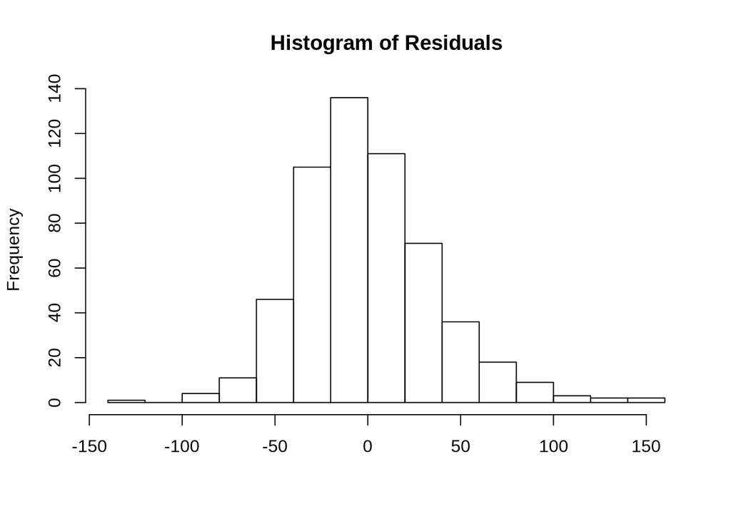

```r
hist(resid(lm_powerlift_senior), xlab = "", main = "Histogram of Residuals")
```

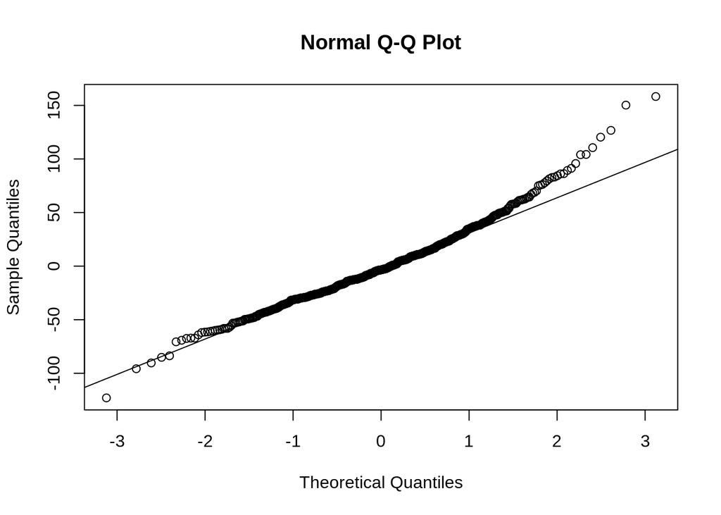

```r
qqnorm(resid(lm_powerlift_senior))
qqline(resid(lm_powerlift_senior))
```

### Summary

- We see that a linear model based on one explanatory variable doesn’t explain the

data well. The $R^2$ value is quite low which shows that the fitted model doesn’t

accuractely predict the values of Senior divisions competitiors bench press best based

on their weight.

- Looking at the summary of the model also shows that the intercept has a high p-value

meaning that the significance can be ignored and is not a good estimate. One good thing

is that the p-value of estimated body weight is a good predictor due to the low p-value

and standard error.

- The residual plots show that even though the distribution of residuals is nearly

normal, the fitted data vs the residuals doesn’t show constant variance and for

larger fitted values, the variance begins to change. A good-fit linear model would

have constant variance or nearly constant variance.